Hi!

If you're here, you're probably interested on how to segment a song in the NTD paradigm. You should read [1] for more details.

This is the goal of this notebook, which can work as a tutorial on how to use the code on your own. Of course, it's related to a version of the code (0.3.0), and should be regularly updated (but this is my job, not yours). Make sure nonetheless that the version you need is also the one of the current version of the notebook.

# Imports

Let's start with external librairies (which are installed automatically if you used `pip install`, otherwise you should install them manually).

```python
# External imports
# Module for manipulating arrays
import numpy as np

# Module for loading signals
import soundfile as sf

# Module handling annotations for MIR datasets (including RWC Pop)
import mirdata

# Module to manipulate tensors, used here to unfold/fold tensors.
import tensorly as tl
```

And now, let's import the `MusicNTD` and `nn_fac` (Nonnegative Factorization) code:

```python
# Module encapsulating the computation of features from the signal
import musicntd.model.features as features

# General module for manipulating data: conversion between time, bars, frame indexes, loading of data, ...
import musicntd.data_manipulation as dm

# Module constructing the tensor, starting from the spectrogram
import musicntd.tensor_factory as tf

# Module containing our NTD resolution algorithm
import nn_fac.ntd as NTD
# Installed automatically with `pip install musicntd`, to install manually from gitlab/pip otherwiee

# Module containing our algorithm used for segmenting the autosimilarity
import musicntd.autosimilarity_segmentation as as_seg

# Plotting module
from musicntd.model.current_plot import *

# Import default paths
import musicntd.scripts.default_path as paths
```

# Loading the song, and its annotations

As an example, we will load the song "POP-01" of RWC Pop. You need to possess the song in wav format on your own, as we don't share it.

For this code to work automaticaly, you should modify the paths variables in the file `default_path.py` in 'musicntd/scripts', with you own path to the wav files.

You can also change the song_path with any of your own song (as a wav), but it could come without annotations.

```python
# Song
song_path = f"{paths.path_entire_rwc}/1.wav"
the_signal, sampling_rate = sf.read(song_path)

# Estimates the downbeats, with madmom
bars = dm.get_bars_from_audio(song_path)
```

We now use the package `mirdata` to load annotations.

```python
# Annotations
rwc_pop = mirdata.initialize('rwc_popular', paths.path_mirdata_rwc)
rwc_pop.download(partial_download=["annotations_sections"])
rwc_song = rwc_pop.track("RM-P001")

references_segments = mirdata.datasets.rwc_popular.load_sections(rwc_song.sections_path).intervals
# Note that it loads 'AIST' annotations, and that we use 'MIREX10' annotations in our tests.
```

[output not shown]

# Spectrogram

Let's compute the spectrogram of the song. We propose either the Mel Spectrorgram or the Nonnegative Log Mel Spectrogram in this code, but you can chose any other feature (either on the file `features.py`, or by looking at the list on the `librosa` package).

```python
# Variables for the tensor-spectrogram.
hop_length = 32
hop_length_seconds = hop_length / sampling_rate
subdivision_bars = 96 # Number of frame per bar in the tensor-spectrogram

# Mel Spectrogram ## NB: called "Grill" because it refers to the paper [2].
spectrogram = features.get_spectrogram(the_signal, sampling_rate, "mel_grill", hop_length)
# NN Log Mel Spectrogram
#spectrogram = features.get_spectrogram(the_signal, sampling_rate, "nn_log_mel_grill", hop_length)
```

and then form the tensor-spectrogram of this spectrogram:

```python
tensor_spectrogram = tf.tensorize_barwise(spectrogram, bars, hop_length_seconds, subdivision_bars)
```

Let's plot the raw barwise autosimilarity of this feature:

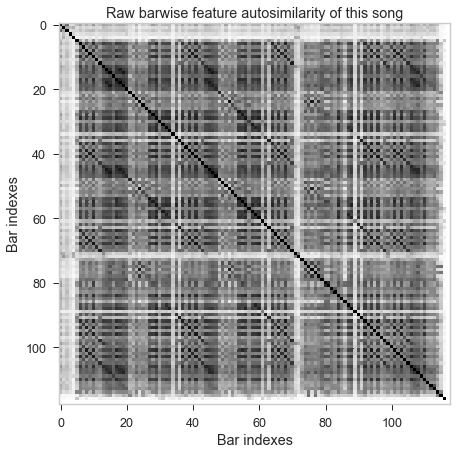

```python
autosimilarity_feature = as_seg.get_autosimilarity(tl.unfold(tensor_spectrogram, 2), transpose = True, normalize = True)
plot_me_this_spectrogram(autosimilarity_feature, title = "Raw barwise feature autosimilarity of this song", x_axis = "Bar indexes", y_axis = "Bar indexes")
```

You can segment this autosimilarity if you want to:

```python
#segments_feature = as_seg.dynamic_convolution_computation(autosimilarity_feature, penalty_weight = 1, penalty_func = "modulo8")[0]
#segments_feature_in_time = dm.segments_from_bar_to_time(segments_feature, bars)
```

# NTD: Nonnegative Tucker Decomposition

Let's compute the Nonnegative Tucker Decomposition of this tensor-spectrogram.

First, we need to set the dimensions of the decomposition, which correspond to the dimensions of the core. They are set empirically here.

```python
ranks = [32,16,16] # Dimensions of the decomposition
```

## Euclidean norm: $\beta$ = 2

Below is presetned the decomposition obtained with the HALS algorithm, optimizing the euclidean norm ($\beta$-divergence with $\beta = 2$) between the original and the reconstructed tensor.

We plot the matrix $Q^T$, corresponding to the barwise representation of the song in terms of patterns. The patterns are defined by the other factors of the decomposition, $W$, $H$ and slices of $G$.

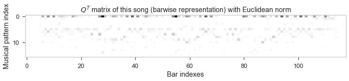

```python
core_beta2, factors_beta2 = NTD.ntd(tensor_spectrogram, ranks = ranks, init = "tucker", verbose = False, deterministic = True,
                                    sparsity_coefficients = [None, None, None, None], normalize = [True, True, False, True], mode_core_norm = 2)

# The plotting function below is defined in current_plot.py
plot_permuted_factor(factors_beta2[2], title = "$Q^T$ matrix of this song (barwise representation) with Euclidean norm", x_axis = "Bar indexes", y_axis = "Musical pattern index")
```

The segmentation is obtained via the autosimilarity matrix of this $Q$ factor, which we plot below:

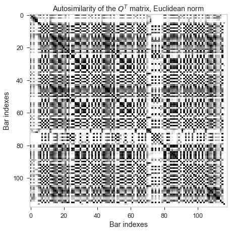

```python
autosimilarity_q_beta2 = as_seg.get_autosimilarity(factors_beta2[2], transpose = True, normalize = True)
plot_me_this_spectrogram(autosimilarity_q_beta2, title = "Autosimilarity of the $Q^T$ matrix, Euclidean norm", x_axis = "Bar indexes", y_axis = "Bar indexes")

# Segmenting this autosimilarity
segments_beta2 = as_seg.dynamic_convolution_computation(autosimilarity_q_beta2, penalty_weight = 1, penalty_func = "modulo8")[0]
segments_beta2_in_time = dm.segments_from_bar_to_time(segments_beta2, bars)
```

Finally, let's compute the segmentation scores:

```python
prec_05, rap_05, f_mes_05 = dm.compute_score_of_segmentation(references_segments, segments_beta2_in_time, window_length = 0.5)
ipd.display(ipd.Markdown("0.5 seconds tolerance: Precision: **{}**, Recall: **{}**, F measure: **{}**".format(round(prec_05,4),round(rap_05,4),round(f_mes_05,4) )))

prec_3, rap_3, f_mes_3 = dm.compute_score_of_segmentation(references_segments, segments_beta2_in_time, window_length = 3)
ipd.display(ipd.Markdown("3 seconds tolerance: Precision: **{}**, Recall: **{}**, F measure: **{}**".format(round(prec_3,4),round(rap_3,4),round(f_mes_3,4) )))
```

0.5 seconds tolerance: Precision: **0.3**, Recall: **0.24**, F measure: **0.2667**

3 seconds tolerance: Precision: **0.7**, Recall: **0.56**, F measure: **0.6222**

## $\beta$ = 1

Let's redo this processus with the MU algorithm optimizing the Kullback-Leibler divergence ($\beta$-divergence with $\beta = 1$):

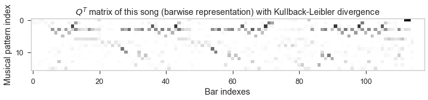

```python
core_beta1, factors_beta1 = NTD.ntd_mu(tensor_spectrogram, ranks = ranks, init = "tucker", verbose = False, deterministic = True, beta = 1,
                                       sparsity_coefficients = [None, None, None, None], normalize = [True, True, False, True], mode_core_norm = 2, n_iter_max = 1000)

# The plotting function below is defined in current_plot.py
plot_permuted_factor(factors_beta1[2], title = "$Q^T$ matrix of this song (barwise representation) with Kullback-Leibler divergence", x_axis = "Bar indexes", y_axis = "Musical pattern index")
```

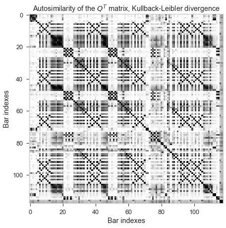

```python
autosimilarity_q_beta1 = as_seg.get_autosimilarity(factors_beta1[2], transpose = True, normalize = True)
plot_me_this_spectrogram(autosimilarity_q_beta1, title = "Autosimilarity of the $Q^T$ matrix, Kullback-Leibler divergence", x_axis = "Bar indexes", y_axis = "Bar indexes")

segments_beta1 = as_seg.dynamic_convolution_computation(autosimilarity_q_beta1, penalty_weight = 1, penalty_func = "modulo8")[0]
segments_beta1_in_time = dm.segments_from_bar_to_time(segments_beta1, bars)
```

```python
prec_05, rap_05, f_mes_05 = dm.compute_score_of_segmentation(references_segments, segments_beta1_in_time, window_length = 0.5)
ipd.display(ipd.Markdown("0.5 seconds tolerance: Precision: **{}**, Recall: **{}**, F measure: **{}**".format(round(prec_05,4),round(rap_05,4),round(f_mes_05,4) )))

prec_3, rap_3, f_mes_3 = dm.compute_score_of_segmentation(references_segments, segments_beta1_in_time, window_length = 3)
ipd.display(ipd.Markdown("3 seconds tolerance: Precision: **{}**, Recall: **{}**, F measure: **{}**".format(round(prec_3,4),round(rap_3,4),round(f_mes_3,4) )))
```

0.5 seconds tolerance: Precision: **0.5455**, Recall: **0.48**, F measure: **0.5106**

3 seconds tolerance: Precision: **0.8182**, Recall: **0.72**, F measure: **0.766**

## $\beta = 0$

Let's redo this processus with the MU algorithm optimizing the Itakura-Saito divergence ($\beta$-divergence with $\beta = 0$):

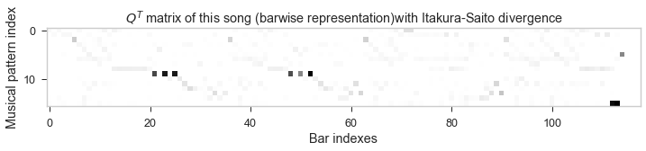

```python
core_beta0, factors_beta0  = NTD.ntd_mu(tensor_spectrogram, ranks = ranks, init = "tucker", verbose = False, deterministic = True, beta = 0,
                                        sparsity_coefficients = [None, None, None, None], normalize = [True, True, False, True], mode_core_norm = 2, n_iter_max = 1000)

# The plotting function below is defined in current_plot.py
plot_permuted_factor(factors_beta0[2], title = "$Q^T$ matrix of this song (barwise representation)with Itakura-Saito divergence", x_axis = "Bar indexes", y_axis = "Musical pattern index")
```

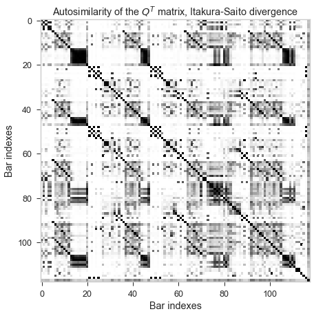

```python
autosimilarity_q_beta0 = as_seg.get_autosimilarity(factors_beta0[2], transpose = True, normalize = True)
plot_me_this_spectrogram(autosimilarity_q_beta0, title = "Autosimilarity of the $Q^T$ matrix, Itakura-Saito divergence", x_axis = "Bar indexes", y_axis = "Bar indexes")

segments_beta0 = as_seg.dynamic_convolution_computation(autosimilarity_q_beta0, penalty_weight = 1, penalty_func = "modulo8")[0]
segments_beta0_in_time = dm.segments_from_bar_to_time(segments_beta0, bars)
```

```python
prec_05, rap_05, f_mes_05 = dm.compute_score_of_segmentation(references_segments, segments_beta0_in_time, window_length = 0.5)
ipd.display(ipd.Markdown("0.5 seconds tolerance: Precision: **{}**, Recall: **{}**, F measure: **{}**".format(round(prec_05,4),round(rap_05,4),round(f_mes_05,4) )))

prec_3, rap_3, f_mes_3 = dm.compute_score_of_segmentation(references_segments, segments_beta0_in_time, window_length = 3)
ipd.display(ipd.Markdown("3 seconds tolerance: Precision: **{}**, Recall: **{}**, F measure: **{}**".format(round(prec_3,4),round(rap_3,4),round(f_mes_3,4) )))
```

0.5 seconds tolerance: Precision: **0.5417**, Recall: **0.52**, F measure: **0.5306**

3 seconds tolerance: Precision: **0.7083**, Recall: **0.68**, F measure: **0.6939**

# References

[1] Marmoret, A., Cohen, J., Bertin, N., & Bimbot, F. (2020, October). Uncovering Audio Patterns in Music with Nonnegative Tucker Decomposition for Structural Segmentation. In ISMIR 2020-21st International Society for Music Information Retrieval.

[2] Grill, T., & Schlüter, J. (2015, October). Music Boundary Detection Using Neural Networks on Combined Features and Two-Level Annotations. In ISMIR (pp. 531-537).